# Risk Factor Analysis

## Outcome Variable

**Outcome Variable:** wast_rec90d

## Predictor Variables

**Intervention Variable:** nrooms

**Adjustment Set:**

unadjusted

## Stratifying Variables

The analysis was stratified on these variable(s):

- agecat
- studyid
- country

## Data Summary

| agecat | studyid | country | nrooms | wast_rec90d | n_cell | n |
| --- | --- | --- | --- | --- | --- | --- |
| 0-24 months | ki0047075b-MAL-ED | BANGLADESH | 4+ | 0 | 3 | 121 |
| 0-24 months | ki0047075b-MAL-ED | BANGLADESH | 4+ | 1 | 1 | 121 |
| 0-24 months | ki0047075b-MAL-ED | BANGLADESH | 1 | 0 | 31 | 121 |
| 0-24 months | ki0047075b-MAL-ED | BANGLADESH | 1 | 1 | 62 | 121 |
| 0-24 months | ki0047075b-MAL-ED | BANGLADESH | 2 | 0 | 7 | 121 |
| 0-24 months | ki0047075b-MAL-ED | BANGLADESH | 2 | 1 | 9 | 121 |
| 0-24 months | ki0047075b-MAL-ED | BANGLADESH | 3 | 0 | 2 | 121 |
| 0-24 months | ki0047075b-MAL-ED | BANGLADESH | 3 | 1 | 6 | 121 |
| 0-24 months | ki0047075b-MAL-ED | BRAZIL | 4+ | 0 | 5 | 24 |
| 0-24 months | ki0047075b-MAL-ED | BRAZIL | 4+ | 1 | 13 | 24 |
| 0-24 months | ki0047075b-MAL-ED | BRAZIL | 1 | 0 | 0 | 24 |
| 0-24 months | ki0047075b-MAL-ED | BRAZIL | 1 | 1 | 0 | 24 |
| 0-24 months | ki0047075b-MAL-ED | BRAZIL | 2 | 0 | 0 | 24 |
| 0-24 months | ki0047075b-MAL-ED | BRAZIL | 2 | 1 | 2 | 24 |
| 0-24 months | ki0047075b-MAL-ED | BRAZIL | 3 | 0 | 1 | 24 |
| 0-24 months | ki0047075b-MAL-ED | BRAZIL | 3 | 1 | 3 | 24 |
| 0-24 months | ki0047075b-MAL-ED | INDIA | 4+ | 0 | 3 | 175 |
| 0-24 months | ki0047075b-MAL-ED | INDIA | 4+ | 1 | 9 | 175 |
| 0-24 months | ki0047075b-MAL-ED | INDIA | 1 | 0 | 26 | 175 |
| 0-24 months | ki0047075b-MAL-ED | INDIA | 1 | 1 | 38 | 175 |
| 0-24 months | ki0047075b-MAL-ED | INDIA | 2 | 0 | 23 | 175 |
| 0-24 months | ki0047075b-MAL-ED | INDIA | 2 | 1 | 42 | 175 |
| 0-24 months | ki0047075b-MAL-ED | INDIA | 3 | 0 | 14 | 175 |
| 0-24 months | ki0047075b-MAL-ED | INDIA | 3 | 1 | 20 | 175 |
| 0-24 months | ki0047075b-MAL-ED | NEPAL | 4+ | 0 | 14 | 97 |
| 0-24 months | ki0047075b-MAL-ED | NEPAL | 4+ | 1 | 41 | 97 |
| 0-24 months | ki0047075b-MAL-ED | NEPAL | 1 | 0 | 4 | 97 |
| 0-24 months | ki0047075b-MAL-ED | NEPAL | 1 | 1 | 24 | 97 |
| 0-24 months | ki0047075b-MAL-ED | NEPAL | 2 | 0 | 1 | 97 |
| 0-24 months | ki0047075b-MAL-ED | NEPAL | 2 | 1 | 7 | 97 |

[output cut: 354 more lines]

The following strata were considered:

- agecat: 0-24 months, studyid: ki0047075b-MAL-ED, country: BANGLADESH
- agecat: 0-24 months, studyid: ki0047075b-MAL-ED, country: BRAZIL
- agecat: 0-24 months, studyid: ki0047075b-MAL-ED, country: INDIA
- agecat: 0-24 months, studyid: ki0047075b-MAL-ED, country: NEPAL
- agecat: 0-24 months, studyid: ki0047075b-MAL-ED, country: PERU
- agecat: 0-24 months, studyid: ki0047075b-MAL-ED, country: SOUTH AFRICA
- agecat: 0-24 months, studyid: ki0047075b-MAL-ED, country: TANZANIA, UNITED REPUBLIC OF
- agecat: 0-24 months, studyid: ki1000108-CMC-V-BCS-2002, country: INDIA
- agecat: 0-24 months, studyid: ki1000108-IRC, country: INDIA
- agecat: 0-24 months, studyid: ki1017093b-PROVIDE, country: BANGLADESH
- agecat: 0-24 months, studyid: ki1017093c-NIH-Crypto, country: BANGLADESH
- agecat: 0-24 months, studyid: ki1113344-GMS-Nepal, country: NEPAL
- agecat: 0-24 months, studyid: ki1114097-CONTENT, country: PERU
- agecat: 0-24 months, studyid: ki1135781-COHORTS, country: INDIA
- agecat: 0-24 months, studyid: kiGH5241-JiVitA-3, country: BANGLADESH
- agecat: 0-24 months, studyid: kiGH5241-JiVitA-4, country: BANGLADESH
- agecat: 0-6 months, studyid: ki0047075b-MAL-ED, country: BANGLADESH
- agecat: 0-6 months, studyid: ki0047075b-MAL-ED, country: BRAZIL
- agecat: 0-6 months, studyid: ki0047075b-MAL-ED, country: INDIA
- agecat: 0-6 months, studyid: ki0047075b-MAL-ED, country: NEPAL
- agecat: 0-6 months, studyid: ki0047075b-MAL-ED, country: PERU
- agecat: 0-6 months, studyid: ki0047075b-MAL-ED, country: SOUTH AFRICA
- agecat: 0-6 months, studyid: ki0047075b-MAL-ED, country: TANZANIA, UNITED REPUBLIC OF
- agecat: 0-6 months, studyid: ki1000108-CMC-V-BCS-2002, country: INDIA
- agecat: 0-6 months, studyid: ki1000108-IRC, country: INDIA
- agecat: 0-6 months, studyid: ki1017093b-PROVIDE, country: BANGLADESH
- agecat: 0-6 months, studyid: ki1017093c-NIH-Crypto, country: BANGLADESH
- agecat: 0-6 months, studyid: ki1113344-GMS-Nepal, country: NEPAL
- agecat: 0-6 months, studyid: ki1114097-CONTENT, country: PERU
- agecat: 0-6 months, studyid: ki1135781-COHORTS, country: INDIA
- agecat: 0-6 months, studyid: kiGH5241-JiVitA-3, country: BANGLADESH
- agecat: 0-6 months, studyid: kiGH5241-JiVitA-4, country: BANGLADESH
- agecat: 6-24 months, studyid: ki0047075b-MAL-ED, country: BANGLADESH
- agecat: 6-24 months, studyid: ki0047075b-MAL-ED, country: BRAZIL
- agecat: 6-24 months, studyid: ki0047075b-MAL-ED, country: INDIA
- agecat: 6-24 months, studyid: ki0047075b-MAL-ED, country: NEPAL
- agecat: 6-24 months, studyid: ki0047075b-MAL-ED, country: PERU
- agecat: 6-24 months, studyid: ki0047075b-MAL-ED, country: SOUTH AFRICA
- agecat: 6-24 months, studyid: ki0047075b-MAL-ED, country: TANZANIA, UNITED REPUBLIC OF
- agecat: 6-24 months, studyid: ki1000108-CMC-V-BCS-2002, country: INDIA
- agecat: 6-24 months, studyid: ki1000108-IRC, country: INDIA
- agecat: 6-24 months, studyid: ki1017093b-PROVIDE, country: BANGLADESH
- agecat: 6-24 months, studyid: ki1017093c-NIH-Crypto, country: BANGLADESH
- agecat: 6-24 months, studyid: ki1113344-GMS-Nepal, country: NEPAL
- agecat: 6-24 months, studyid: ki1114097-CONTENT, country: PERU
- agecat: 6-24 months, studyid: ki1135781-COHORTS, country: INDIA
- agecat: 6-24 months, studyid: kiGH5241-JiVitA-3, country: BANGLADESH
- agecat: 6-24 months, studyid: kiGH5241-JiVitA-4, country: BANGLADESH

### Dropped Strata

Some strata were dropped due to rare outcomes:

- agecat: 0-24 months, studyid: ki0047075b-MAL-ED, country: BANGLADESH
- agecat: 0-24 months, studyid: ki0047075b-MAL-ED, country: BRAZIL
- agecat: 0-24 months, studyid: ki0047075b-MAL-ED, country: INDIA
- agecat: 0-24 months, studyid: ki0047075b-MAL-ED, country: NEPAL
- agecat: 0-24 months, studyid: ki0047075b-MAL-ED, country: PERU
- agecat: 0-24 months, studyid: ki0047075b-MAL-ED, country: SOUTH AFRICA
- agecat: 0-24 months, studyid: ki0047075b-MAL-ED, country: TANZANIA, UNITED REPUBLIC OF
- agecat: 0-24 months, studyid: ki1000108-CMC-V-BCS-2002, country: INDIA
- agecat: 0-24 months, studyid: ki1017093b-PROVIDE, country: BANGLADESH
- agecat: 0-24 months, studyid: ki1114097-CONTENT, country: PERU
- agecat: 0-24 months, studyid: ki1135781-COHORTS, country: INDIA
- agecat: 0-6 months, studyid: ki0047075b-MAL-ED, country: BANGLADESH
- agecat: 0-6 months, studyid: ki0047075b-MAL-ED, country: BRAZIL
- agecat: 0-6 months, studyid: ki0047075b-MAL-ED, country: INDIA
- agecat: 0-6 months, studyid: ki0047075b-MAL-ED, country: NEPAL
- agecat: 0-6 months, studyid: ki0047075b-MAL-ED, country: PERU
- agecat: 0-6 months, studyid: ki0047075b-MAL-ED, country: SOUTH AFRICA
- agecat: 0-6 months, studyid: ki0047075b-MAL-ED, country: TANZANIA, UNITED REPUBLIC OF
- agecat: 0-6 months, studyid: ki1000108-CMC-V-BCS-2002, country: INDIA
- agecat: 0-6 months, studyid: ki1000108-IRC, country: INDIA
- agecat: 0-6 months, studyid: ki1017093b-PROVIDE, country: BANGLADESH
- agecat: 0-6 months, studyid: ki1017093c-NIH-Crypto, country: BANGLADESH
- agecat: 0-6 months, studyid: ki1114097-CONTENT, country: PERU
- agecat: 0-6 months, studyid: ki1135781-COHORTS, country: INDIA
- agecat: 6-24 months, studyid: ki0047075b-MAL-ED, country: BANGLADESH
- agecat: 6-24 months, studyid: ki0047075b-MAL-ED, country: BRAZIL
- agecat: 6-24 months, studyid: ki0047075b-MAL-ED, country: INDIA
- agecat: 6-24 months, studyid: ki0047075b-MAL-ED, country: NEPAL
- agecat: 6-24 months, studyid: ki0047075b-MAL-ED, country: PERU
- agecat: 6-24 months, studyid: ki0047075b-MAL-ED, country: SOUTH AFRICA
- agecat: 6-24 months, studyid: ki0047075b-MAL-ED, country: TANZANIA, UNITED REPUBLIC OF
- agecat: 6-24 months, studyid: ki1000108-CMC-V-BCS-2002, country: INDIA
- agecat: 6-24 months, studyid: ki1000108-IRC, country: INDIA
- agecat: 6-24 months, studyid: ki1017093b-PROVIDE, country: BANGLADESH
- agecat: 6-24 months, studyid: ki1017093c-NIH-Crypto, country: BANGLADESH
- agecat: 6-24 months, studyid: ki1114097-CONTENT, country: PERU
- agecat: 6-24 months, studyid: ki1135781-COHORTS, country: INDIA
- agecat: 6-24 months, studyid: kiGH5241-JiVitA-3, country: BANGLADESH

## Methods Detail

We’re interested in the causal parameters $E[Y_a]$ for all values of $a \in \mathcal{A}$. These parameters represent the mean outcome if, possibly contrary to fact, we intervened to set all units to have $A=a$. Under the randomization and positivity assumptions, these are identified by the statistical parameters $\psi_a=E_W[E_{Y|A,W}(Y|A=a,W)]$. In addition, we’re interested in the mean of $Y$, $E[Y]$ under no intervention (the observed mean). We will estimate these parameters by using SuperLearner to fit the relevant likelihood factors – $E_{Y|A,W}(Y|A=a,W)$ and $p(A=a|W)$, and then updating our likelihood fit using a joint TMLE.

For unadjusted analyses ($W=\{\}$), initial likelihoods were estimated using Lrnr_glm to estimate the simple $E(Y|A)$ and Lrnr_mean to estimate $p(A)$. For adjusted analyses, a small library containing Lrnr_glmnet, Lrnr_xgboost, and Lrnr_mean was used.

Having estimated these parameters, we will then use the delta method to estimate relative risks and attributable risks relative to a prespecified baseline level of $A$.

# Results Detail

## Results Plots

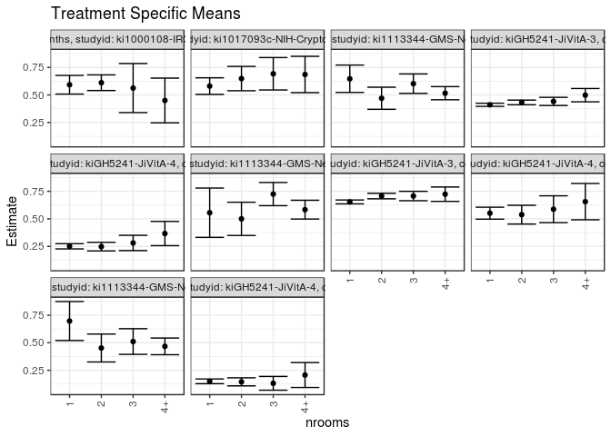

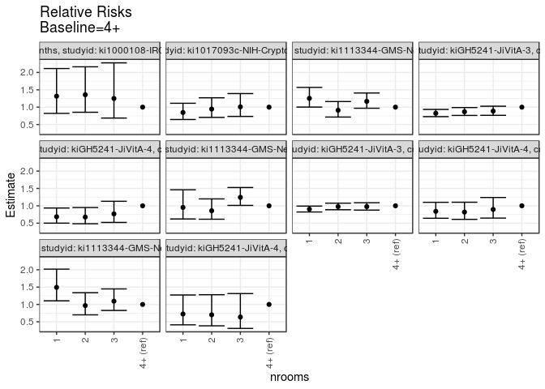

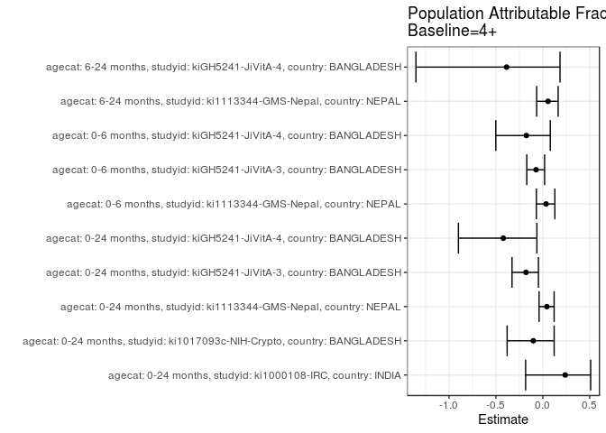

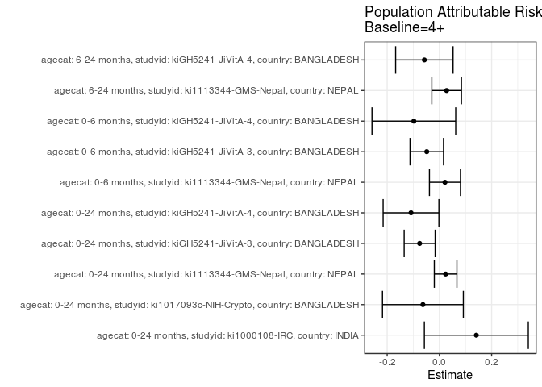

## Results Table

### Parameter: TSM

| agecat | studyid | country | intervention_level | baseline_level | estimate | ci_lower | ci_upper |
| --- | --- | --- | --- | --- | --- | --- | --- |
| 0-24 months | ki1000108-IRC | INDIA | 4+ | NA | 0.4500000 | 0.2471890 | 0.6528110 |
| 0-24 months | ki1000108-IRC | INDIA | 1 | NA | 0.5925926 | 0.5081592 | 0.6770260 |
| 0-24 months | ki1000108-IRC | INDIA | 2 | NA | 0.6111111 | 0.5401543 | 0.6820679 |
| 0-24 months | ki1000108-IRC | INDIA | 3 | NA | 0.5625000 | 0.3398407 | 0.7851593 |
| 0-24 months | ki1017093c-NIH-Crypto | BANGLADESH | 4+ | NA | 0.6857143 | 0.5209342 | 0.8504944 |
| 0-24 months | ki1017093c-NIH-Crypto | BANGLADESH | 1 | NA | 0.5802469 | 0.5049956 | 0.6554982 |
| 0-24 months | ki1017093c-NIH-Crypto | BANGLADESH | 2 | NA | 0.6486486 | 0.5382188 | 0.7590785 |
| 0-24 months | ki1017093c-NIH-Crypto | BANGLADESH | 3 | NA | 0.6923077 | 0.5453040 | 0.8393114 |
| 0-24 months | ki1113344-GMS-Nepal | NEPAL | 4+ | NA | 0.5159236 | 0.4561954 | 0.5756518 |
| 0-24 months | ki1113344-GMS-Nepal | NEPAL | 1 | NA | 0.6470588 | 0.5229282 | 0.7711895 |
| 0-24 months | ki1113344-GMS-Nepal | NEPAL | 2 | NA | 0.4700855 | 0.3697893 | 0.5703817 |
| 0-24 months | ki1113344-GMS-Nepal | NEPAL | 3 | NA | 0.6024845 | 0.5143128 | 0.6906561 |
| 0-24 months | kiGH5241-JiVitA-3 | BANGLADESH | 4+ | NA | 0.4980989 | 0.4376678 | 0.5585299 |
| 0-24 months | kiGH5241-JiVitA-3 | BANGLADESH | 1 | NA | 0.4106708 | 0.3963098 | 0.4250318 |
| 0-24 months | kiGH5241-JiVitA-3 | BANGLADESH | 2 | NA | 0.4322115 | 0.4110522 | 0.4533709 |
| 0-24 months | kiGH5241-JiVitA-3 | BANGLADESH | 3 | NA | 0.4414286 | 0.4044585 | 0.4783986 |
| 0-24 months | kiGH5241-JiVitA-4 | BANGLADESH | 4+ | NA | 0.3666667 | 0.2567234 | 0.4766099 |
| 0-24 months | kiGH5241-JiVitA-4 | BANGLADESH | 1 | NA | 0.2507837 | 0.2270319 | 0.2745355 |
| 0-24 months | kiGH5241-JiVitA-4 | BANGLADESH | 2 | NA | 0.2480159 | 0.2088977 | 0.2871340 |
| 0-24 months | kiGH5241-JiVitA-4 | BANGLADESH | 3 | NA | 0.2812500 | 0.2120372 | 0.3504628 |
| 0-6 months | ki1113344-GMS-Nepal | NEPAL | 4+ | NA | 0.5833333 | 0.4981147 | 0.6685520 |
| 0-6 months | ki1113344-GMS-Nepal | NEPAL | 1 | NA | 0.5555556 | 0.3318457 | 0.7792654 |
| 0-6 months | ki1113344-GMS-Nepal | NEPAL | 2 | NA | 0.5000000 | 0.3491063 | 0.6508937 |
| 0-6 months | ki1113344-GMS-Nepal | NEPAL | 3 | NA | 0.7246377 | 0.6194642 | 0.8298111 |
| 0-6 months | kiGH5241-JiVitA-3 | BANGLADESH | 4+ | NA | 0.7237569 | 0.6585820 | 0.7889318 |
| 0-6 months | kiGH5241-JiVitA-3 | BANGLADESH | 1 | NA | 0.6533991 | 0.6358917 | 0.6709065 |
| 0-6 months | kiGH5241-JiVitA-3 | BANGLADESH | 2 | NA | 0.7067610 | 0.6817298 | 0.7317922 |
| 0-6 months | kiGH5241-JiVitA-3 | BANGLADESH | 3 | NA | 0.7070938 | 0.6645307 | 0.7496569 |
| 0-6 months | kiGH5241-JiVitA-4 | BANGLADESH | 4+ | NA | 0.6562500 | 0.4915378 | 0.8209622 |
| 0-6 months | kiGH5241-JiVitA-4 | BANGLADESH | 1 | NA | 0.5514019 | 0.4969447 | 0.6058590 |
| 0-6 months | kiGH5241-JiVitA-4 | BANGLADESH | 2 | NA | 0.5378788 | 0.4527497 | 0.6230079 |
| 0-6 months | kiGH5241-JiVitA-4 | BANGLADESH | 3 | NA | 0.5873016 | 0.4656210 | 0.7089822 |
| 6-24 months | ki1113344-GMS-Nepal | NEPAL | 4+ | NA | 0.4670330 | 0.3913393 | 0.5427267 |
| 6-24 months | ki1113344-GMS-Nepal | NEPAL | 1 | NA | 0.6969697 | 0.5201686 | 0.8737708 |
| 6-24 months | ki1113344-GMS-Nepal | NEPAL | 2 | NA | 0.4520548 | 0.3254929 | 0.5786167 |
| 6-24 months | ki1113344-GMS-Nepal | NEPAL | 3 | NA | 0.5108696 | 0.3944329 | 0.6273063 |
| 6-24 months | kiGH5241-JiVitA-4 | BANGLADESH | 4+ | NA | 0.2068966 | 0.0939355 | 0.3198576 |
| 6-24 months | kiGH5241-JiVitA-4 | BANGLADESH | 1 | NA | 0.1497382 | 0.1283680 | 0.1711084 |
| 6-24 months | kiGH5241-JiVitA-4 | BANGLADESH | 2 | NA | 0.1451613 | 0.1085956 | 0.1817269 |
| 6-24 months | kiGH5241-JiVitA-4 | BANGLADESH | 3 | NA | 0.1317829 | 0.0692086 | 0.1943573 |

### Parameter: E(Y)

| agecat | studyid | country | intervention_level | baseline_level | estimate | ci_lower | ci_upper |
| --- | --- | --- | --- | --- | --- | --- | --- |
| 0-24 months | ki1000108-IRC | INDIA | NA | NA | 0.5913706 | 0.5391835 | 0.6435576 |
| 0-24 months | ki1017093c-NIH-Crypto | BANGLADESH | NA | NA | 0.6225806 | 0.5684562 | 0.6767051 |
| 0-24 months | ki1113344-GMS-Nepal | NEPAL | NA | NA | 0.5396579 | 0.4973524 | 0.5819633 |
| 0-24 months | kiGH5241-JiVitA-3 | BANGLADESH | NA | NA | 0.4224868 | 0.4113573 | 0.4336163 |
| 0-24 months | kiGH5241-JiVitA-4 | BANGLADESH | NA | NA | 0.2580019 | 0.2386523 | 0.2773515 |
| 0-6 months | ki1113344-GMS-Nepal | NEPAL | NA | NA | 0.6045627 | 0.5449300 | 0.6641955 |
| 0-6 months | kiGH5241-JiVitA-3 | BANGLADESH | NA | NA | 0.6754071 | 0.6620619 | 0.6887522 |
| 0-6 months | kiGH5241-JiVitA-4 | BANGLADESH | NA | NA | 0.5583942 | 0.5167799 | 0.6000084 |
| 6-24 months | ki1113344-GMS-Nepal | NEPAL | NA | NA | 0.4947368 | 0.4401559 | 0.5493178 |
| 6-24 months | kiGH5241-JiVitA-4 | BANGLADESH | NA | NA | 0.1492734 | 0.1316631 | 0.1668838 |

### Parameter: RR

| agecat | studyid | country | intervention_level | baseline_level | estimate | ci_lower | ci_upper |
| --- | --- | --- | --- | --- | --- | --- | --- |
| 0-24 months | ki1000108-IRC | INDIA | 4+ | 4+ | 1.0000000 | 1.0000000 | 1.0000000 |
| 0-24 months | ki1000108-IRC | INDIA | 1 | 4+ | 1.3168724 | 0.8208567 | 2.1126135 |
| 0-24 months | ki1000108-IRC | INDIA | 2 | 4+ | 1.3580247 | 0.8527213 | 2.1627595 |
| 0-24 months | ki1000108-IRC | INDIA | 3 | 4+ | 1.2500000 | 0.6860395 | 2.2775656 |
| 0-24 months | ki1017093c-NIH-Crypto | BANGLADESH | 4+ | 4+ | 1.0000000 | 1.0000000 | 1.0000000 |
| 0-24 months | ki1017093c-NIH-Crypto | BANGLADESH | 1 | 4+ | 0.8461934 | 0.6440264 | 1.1118230 |
| 0-24 months | ki1017093c-NIH-Crypto | BANGLADESH | 2 | 4+ | 0.9459459 | 0.7046622 | 1.2698478 |
| 0-24 months | ki1017093c-NIH-Crypto | BANGLADESH | 3 | 4+ | 1.0096154 | 0.7326591 | 1.3912654 |
| 0-24 months | ki1113344-GMS-Nepal | NEPAL | 4+ | 4+ | 1.0000000 | 1.0000000 | 1.0000000 |
| 0-24 months | ki1113344-GMS-Nepal | NEPAL | 1 | 4+ | 1.2541757 | 1.0023703 | 1.5692372 |
| 0-24 months | ki1113344-GMS-Nepal | NEPAL | 2 | 4+ | 0.9111533 | 0.7147455 | 1.1615328 |
| 0-24 months | ki1113344-GMS-Nepal | NEPAL | 3 | 4+ | 1.1677785 | 0.9689629 | 1.4073880 |
| 0-24 months | kiGH5241-JiVitA-3 | BANGLADESH | 4+ | 4+ | 1.0000000 | 1.0000000 | 1.0000000 |
| 0-24 months | kiGH5241-JiVitA-3 | BANGLADESH | 1 | 4+ | 0.8244765 | 0.7266799 | 0.9354345 |
| 0-24 months | kiGH5241-JiVitA-3 | BANGLADESH | 2 | 4+ | 0.8677224 | 0.7613121 | 0.9890058 |
| 0-24 months | kiGH5241-JiVitA-3 | BANGLADESH | 3 | 4+ | 0.8862268 | 0.7647506 | 1.0269988 |
| 0-24 months | kiGH5241-JiVitA-4 | BANGLADESH | 4+ | 4+ | 1.0000000 | 1.0000000 | 1.0000000 |
| 0-24 months | kiGH5241-JiVitA-4 | BANGLADESH | 1 | 4+ | 0.6839555 | 0.4994260 | 0.9366656 |
| 0-24 months | kiGH5241-JiVitA-4 | BANGLADESH | 2 | 4+ | 0.6764069 | 0.4820314 | 0.9491630 |
| 0-24 months | kiGH5241-JiVitA-4 | BANGLADESH | 3 | 4+ | 0.7670455 | 0.5204155 | 1.1305557 |
| 0-6 months | ki1113344-GMS-Nepal | NEPAL | 4+ | 4+ | 1.0000000 | 1.0000000 | 1.0000000 |
| 0-6 months | ki1113344-GMS-Nepal | NEPAL | 1 | 4+ | 0.9523810 | 0.6205522 | 1.4616490 |
| 0-6 months | ki1113344-GMS-Nepal | NEPAL | 2 | 4+ | 0.8571429 | 0.6129707 | 1.1985790 |
| 0-6 months | ki1113344-GMS-Nepal | NEPAL | 3 | 4+ | 1.2422360 | 1.0110429 | 1.5262956 |
| 0-6 months | kiGH5241-JiVitA-3 | BANGLADESH | 4+ | 4+ | 1.0000000 | 1.0000000 | 1.0000000 |
| 0-6 months | kiGH5241-JiVitA-3 | BANGLADESH | 1 | 4+ | 0.9027880 | 0.8218313 | 0.9917196 |
| 0-6 months | kiGH5241-JiVitA-3 | BANGLADESH | 2 | 4+ | 0.9765171 | 0.8864521 | 1.0757329 |
| 0-6 months | kiGH5241-JiVitA-3 | BANGLADESH | 3 | 4+ | 0.9769770 | 0.8766837 | 1.0887438 |
| 0-6 months | kiGH5241-JiVitA-4 | BANGLADESH | 4+ | 4+ | 1.0000000 | 1.0000000 | 1.0000000 |
| 0-6 months | kiGH5241-JiVitA-4 | BANGLADESH | 1 | 4+ | 0.8402314 | 0.6415940 | 1.1003670 |
| 0-6 months | kiGH5241-JiVitA-4 | BANGLADESH | 2 | 4+ | 0.8196248 | 0.6091858 | 1.1027586 |
| 0-6 months | kiGH5241-JiVitA-4 | BANGLADESH | 3 | 4+ | 0.8949358 | 0.6463204 | 1.2391842 |
| 6-24 months | ki1113344-GMS-Nepal | NEPAL | 4+ | 4+ | 1.0000000 | 1.0000000 | 1.0000000 |
| 6-24 months | ki1113344-GMS-Nepal | NEPAL | 1 | 4+ | 1.4923351 | 1.1042417 | 2.0168267 |
| 6-24 months | ki1113344-GMS-Nepal | NEPAL | 2 | 4+ | 0.9679291 | 0.7002806 | 1.3378733 |
| 6-24 months | ki1113344-GMS-Nepal | NEPAL | 3 | 4+ | 1.0938619 | 0.8268902 | 1.4470286 |
| 6-24 months | kiGH5241-JiVitA-4 | BANGLADESH | 4+ | 4+ | 1.0000000 | 1.0000000 | 1.0000000 |
| 6-24 months | kiGH5241-JiVitA-4 | BANGLADESH | 1 | 4+ | 0.7237347 | 0.4116305 | 1.2724811 |
| 6-24 months | kiGH5241-JiVitA-4 | BANGLADESH | 2 | 4+ | 0.7016129 | 0.3845613 | 1.2800578 |
| 6-24 months | kiGH5241-JiVitA-4 | BANGLADESH | 3 | 4+ | 0.6369509 | 0.3089293 | 1.3132663 |

### Parameter: PAR

| agecat | studyid | country | intervention_level | baseline_level | estimate | ci_lower | ci_upper |
| --- | --- | --- | --- | --- | --- | --- | --- |
| 0-24 months | ki1000108-IRC | INDIA | 4+ | NA | 0.1413706 | -0.0576416 | 0.3403827 |
| 0-24 months | ki1017093c-NIH-Crypto | BANGLADESH | 4+ | NA | -0.0631336 | -0.2179095 | 0.0916422 |
| 0-24 months | ki1113344-GMS-Nepal | NEPAL | 4+ | NA | 0.0237343 | -0.0195251 | 0.0669937 |
| 0-24 months | kiGH5241-JiVitA-3 | BANGLADESH | 4+ | NA | -0.0756121 | -0.1349546 | -0.0162696 |
| 0-24 months | kiGH5241-JiVitA-4 | BANGLADESH | 4+ | NA | -0.1086647 | -0.2154256 | -0.0019038 |
| 0-6 months | ki1113344-GMS-Nepal | NEPAL | 4+ | NA | 0.0212294 | -0.0381741 | 0.0806329 |
| 0-6 months | kiGH5241-JiVitA-3 | BANGLADESH | 4+ | NA | -0.0483498 | -0.1123866 | 0.0156869 |
| 0-6 months | kiGH5241-JiVitA-4 | BANGLADESH | 4+ | NA | -0.0978558 | -0.2581474 | 0.0624357 |
| 6-24 months | ki1113344-GMS-Nepal | NEPAL | 4+ | NA | 0.0277039 | -0.0289729 | 0.0843807 |
| 6-24 months | kiGH5241-JiVitA-4 | BANGLADESH | 4+ | NA | -0.0576231 | -0.1675715 | 0.0523253 |

### Parameter: PAF

| agecat | studyid | country | intervention_level | baseline_level | estimate | ci_lower | ci_upper |
| --- | --- | --- | --- | --- | --- | --- | --- |
| 0-24 months | ki1000108-IRC | INDIA | 4+ | NA | 0.2390558 | -0.1833208 | 0.5106685 |
| 0-24 months | ki1017093c-NIH-Crypto | BANGLADESH | 4+ | NA | -0.1014064 | -0.3803220 | 0.1211500 |
| 0-24 months | ki1113344-GMS-Nepal | NEPAL | 4+ | NA | 0.0439802 | -0.0396218 | 0.1208594 |
| 0-24 months | kiGH5241-JiVitA-3 | BANGLADESH | 4+ | NA | -0.1789691 | -0.3282015 | -0.0465040 |
| 0-24 months | kiGH5241-JiVitA-4 | BANGLADESH | 4+ | NA | -0.4211779 | -0.8999044 | -0.0630781 |
| 0-6 months | ki1113344-GMS-Nepal | NEPAL | 4+ | NA | 0.0351153 | -0.0684841 | 0.1286698 |
| 0-6 months | kiGH5241-JiVitA-3 | BANGLADESH | 4+ | NA | -0.0715862 | -0.1707587 | 0.0191856 |
| 0-6 months | kiGH5241-JiVitA-4 | BANGLADESH | 4+ | NA | -0.1752451 | -0.5011455 | 0.0799020 |
| 6-24 months | ki1113344-GMS-Nepal | NEPAL | 4+ | NA | 0.0559972 | -0.0654705 | 0.1636171 |
| 6-24 months | kiGH5241-JiVitA-4 | BANGLADESH | 4+ | NA | -0.3860238 | -1.3532606 | 0.1836595 |